# Technical Applications & Data Analytics (WS 2021)

Game Design & Management (B. A.)

Autor:in

Zugehörigkeiten

© Benjamin Gross

Hochschule Fresenius - University of Applied Sciences

Email: benjamin.gross@ext-hs.fresenius.de

Website: https://drbenjamin.github.io

Zusammenfassung

Dieses Dokument enthält das Kursmaterial für die Veranstaltung Technical Applications & Data Analytics im Bachelorstudiengang Game Design & Management. Es behandelt grundlegende Konzepte der Datenanalyse und -verarbeitung, technische Applikationen wie Microsoft Excel (VBA) und R, verschiedene Datenquellen und deren Zusammenhänge, Speicherung von Daten in Datenbanken und Data Warehouses, sowie wichtige Data Mining Methoden einschließlich Korrelationsanalyse, lineare Regressionsanalyse, Basket-Analyse, Cluster-Analyse K-Means und neuronale Netze. Darüber hinaus werden ethische Aspekte der Datenanalyse und Datenschutzfragen diskutiert.

# Technical Applications & Data Analytics

Dies ist der Kursinhalt für die Veranstaltung *Technical Applications & Data Analytics* im Bachelorstudiengang *Game Design & Management* an der *Hochschule Fresenius - University of Applied Sciences*.

## Vorstellungsrunde

[figure not shown]

Vorstellung

## Einleitung

### Lernziele

*oder auch: Wie erreiche ich in Zukunft die „Daten-Weltherrschaft“?!*

- Datenarten verarbeiten, erstellen und analysieren
- Vor- und Nachteile von Methoden und Applikationen einschätzen können
- verschiedene Applikation beurteilen und einordnen können
- Open Source Applikationen bedienen können
- theoretische Analyse der Algorithmen und Interpretation der Ergebnisse

### Gegenwartsbezug

*oder auch: Was hat das mit mir und meiner Zukunft zu tun?!*

- Für die Wirtschaft bestehst Du mittlerweile fast ausschließlich aus einer Flut an Daten
- Ethik vs. Wirtschaft
- Vorteile der Technik nutzen (z.B. Medizin)
- Was kann ein datenschutzkonformer Ansatz Gutes bewirken?
- Die Datenverarbeitung wird immer automatisierter, neue Jobs werden geschaffen

### Der “Fragebogen”

*oder auch: Was sind heute die wirklich wichtigen Fragen?!*

Als Excel-Makro Code-Beispiel (VBA) auf Ilias verfügbar! *Die Excel-Makro-Datei (xlsm) wird regelmäßig aktualisiert, da sie sich in der Entwicklung befindet – daher regelmäßig den aktuellen Stand downloaden!*

**Der „Fragebogen“** oder auch: Was sind heute die wirklich wichtigen Fragen?!

### Gliederung

[figure not shown]

Gliederung

### Grundbegriffe des Technical Applications & Data Management

- Geschichte der Datenanalyse und Datenverarbeitung (incl. Hardware)
- Bedeutung von Daten und deren Digitalisierung
- Ziele der Datenanalyse und Stand der Technik der Datenanalyse
- Einführung in die Begriffe BI, Reporting und Big Data

**Definition Statistik:** Wissenschaft von Sammlung, Analyse und Interpretation und Kommunikation von Daten mithilfe mathematischer Verfahren zur Entscheidungsfindung.

**Definition Datenanalyse:** Der Prozess des Erhebens von Daten, ihrer Auswertung und Interpretation.

**Definition Datenverarbeitung:** Der Prozess des Datensammelns und deren Umwandlung in nützliche Informationen. Es werden mit angemessenen Techniken (ohne die gewünschten Daten zu beeinträchtigen) Rohdaten in ein besser lesbares Format (Graphen, Dokumente etc.) umwandelt. Die Daten erhalten so die nötige Form und den erforderlichen Kontext, damit sie von Computern interpretiert und von Mitarbeitern in der gesamten Organisation genutzt werden können (Romeijn, 2016; Tukey, 1962)

#### 1.a) Geschichte der Datenanalyse und Datenverarbeitung (incl. Hardware)

- 1934 – 1941: ZUSE Z1, Z2 und Z3 von Konrad Zuse in Relaistechnik (elektromagnetischer Schalter)
- 1945: Idee des Programms (Arbeitsanweisung für den Computer) von John von Neumann
- 1954: Entwicklung der ersten Programmiersprache FORTRAN (Formula Translation; eine Mischung aus wenigen englischen Wörtern, mathematischen Symbolen & Gestaltungsvorschriften)
- 1980: Entwicklung von Mikroprozessoren auf Siliziumbasis
- 1985: Personal Computer von IBM mit Betriebssystem Windows (Abb. 1.a.1)
- 1983: TCP/IP-Protokoll im ARPANET (Vorläufer Internet, aktuell IPv4/6)
- 1989: HTML Entwurf (Hyper Text Markup Language)

[figure not shown]

Abb. 1.a.1: Microsoft Windows 1.01

##### Computer Hardwareentwicklung

- Generation 0 (bis 1945)
- Mechanik für Addition
- Generation 1 (1945 – 1955)
- Röhren in Maschinensprache fest programmiert
- Generation 2 (1955 - 1965)
- Transistoren mit Stapelverarbeitung
- Generation 3 (1965 - 1980)
- integrierte Schaltungen (IC), IBM System/360
- Generation 4 (1980 - 1990)
- Personal Computer (PC), IBM PC Modell 5150
- Generation 5 (1990 - ?)
- Laptops, PDAs, Mobiltelefon, etc.

[figure not shown]

Abb. 1.a.2: IBM System/360

##### Betriebssysteme und Erscheinungsjahr

- **Unix (1969)**
- **MS-DOS (1981)**
- **Windows (1985)**
- **Linux (1991)**
  - Distributionen (https://en.wikipedia.org/wiki/List_of_Linux_distributions)
    - Debian (1993)
    - Red Hat Linux (1994)
    - Ubuntu (2004)
- **MacOS (2001)**

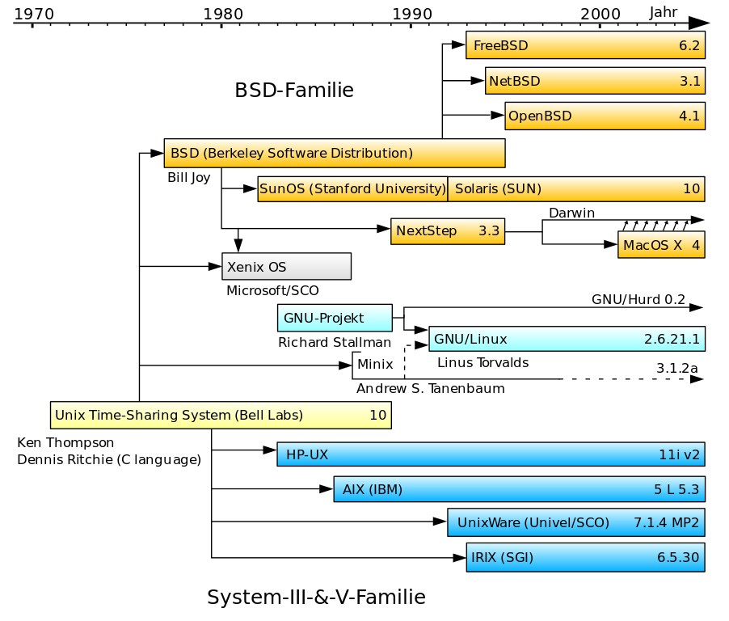

Abb. 1.a.2: Betriebssystem Unix Timeline

##### Programmiersprachen und Erscheinungsjahr

[figure not shown]

Abb. 1.a.3: Programmiersprachen im Ranking

- Assembler (~ Maschinensprache - aber kein ByteCode, seit 1950)
- Fortran (1957)
- Basic (1964)
- Pascal (1971)
- C (1972) / C++ (1985)
- Python (1991)
- Visual Basic (1991) / **VBA (1995)**
- **R (1993)**
- Java (1995) / JavaScript (1995)
- PHP (1995)
- C# (2001)
- Swift (2014), Objective-C (1984)
- Low Code: z.B. Scratch (2007), **Power Fx / Power Apps (2021)**

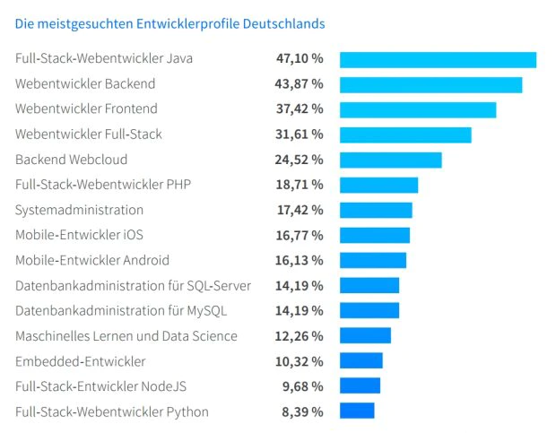

Abb. 1.a.4: Jobs als Programmierer im Ranking

##### Programmierparadigmen / Programmierstile

- **Strukturierte Programmierung**
  - baumartige Zerlegung
  - eigeschränkte Verwendung von Sprunganweisungen (GOTO)
- **Prozeduale Programmierung**
  - Aufruf von Prozeduren (geordnete Liste von auszuführenden Anweisungen)
  - Prozeduren können andere oder von anderen Prozeduren aufgerufen werden
- **Modulare Programmierung**
  - Programme bestehen of aus Modulen (Teile eines Programmes)
- **Objektorientierte Programmierung**
  - (Objekt ist eine Datenstruktur, ähnelt einem realen Objekt)
  - Flexibilität und Wartbarkeit, können einfach verteilt entwickelt werden

##### Entwicklungsumgebungen (IDE ~ Integrated Development Enviroment)

- **Eclipse**
  - Java, auch fast alle anderen
- **IntelliJ IDEA**
  - Java
- **NetBeans IDE**
  - Java, PHP, C++
- **Android Studio**
  - Java, Android SDKs
- **Visual Studio (Code)**
  - .Net, Studio Code alle Sprachen
- **R Studio**
  - Data Mining, Statistik
- **Apple XCode**
  - Swift und Objective-C für die Systeme macOS, iOS, watchOS und TvOS

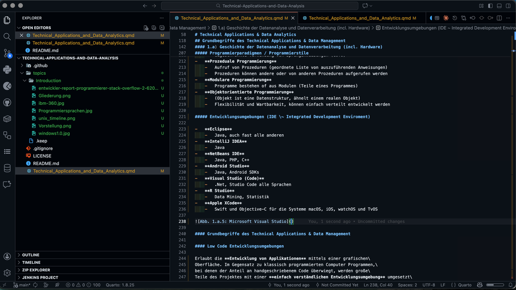

Abb. 1.a.5: Microsoft Visual Studio

##### Low Code Entwicklungsumgebungen

Erlaubt die **Entwicklung von Applikationen** mittels einer grafischen  
Oberfläche. Im Gegensatz zu klassisch programmierten Computer Programmen,  
bei denen der Anteil an handgeschriebenem Code überwiegt, werden große  
Teile des Projektes mit einer **einfach verständlichen Entwicklungsumgebung** umgesetzt  
(vgl. *Rapidminer* oder Microsoft  
Power Apps).

Für Kinder und Jugendliche gibt es z.B. mit *Scratch* und *Game Builder Garage* für die *Nintendo Switch* Umgebungen zum Erlernen von Basisfähigkeiten der (Spiele-) Programmierung.

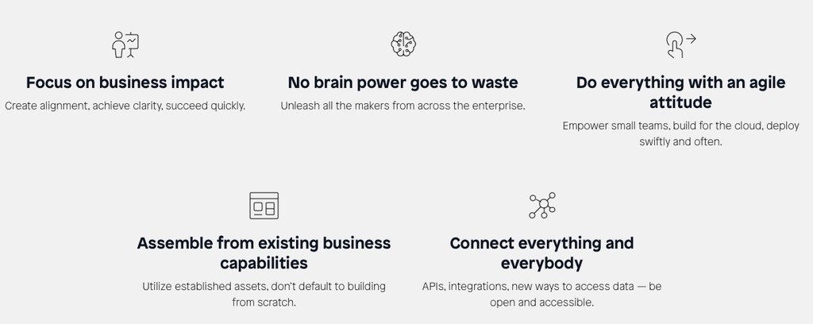

Abb. 1.a.6: Säulen der Low Code Entwicklung

##### Projektmanagement

Laut der **DIN 69901-5:2009** ist ein Projekt ein Vorhaben, das im Wesentlichen durch Einmaligkeit der Bedingungen in ihrer Gesamtheit gekennzeichnet ist (im Gegensatz zur Linienproduktion).

Ziel ist nach dieser Definition, dass Projekte **richtig geplant** und **gesteuert** werden, dass die **Risiken begrenzt**, **Chancen genutzt** und **Projektziele qualitativ**, **termingerecht** und **im Kostenrahmen erreicht** werden.

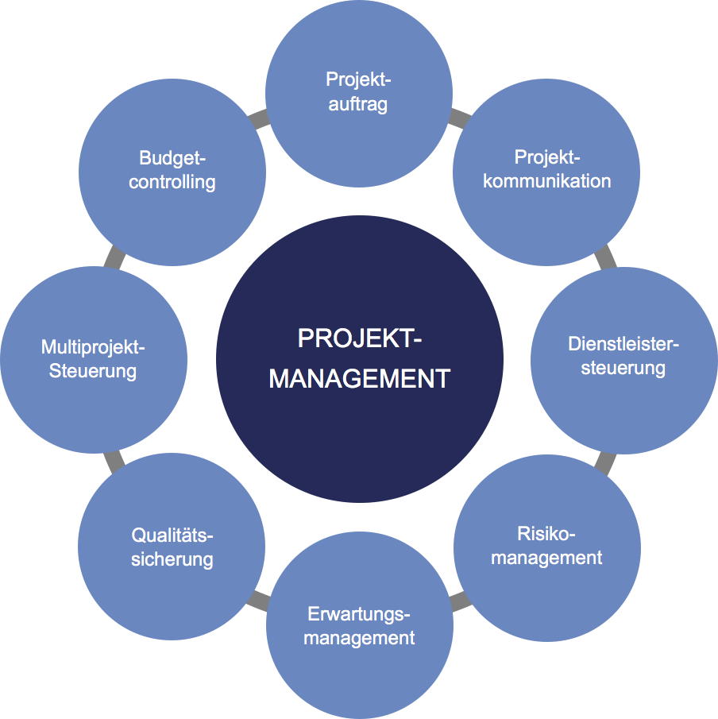

Abb. 1.a.7: Projektmanagement Prozess

##### Agiles Projektmanagement

**SCRUM** ist ein Framework, das für die Produktentwicklung in Teamarbeit verwendet werden kann.

Ursprünglich wurde diese Methodik nur bei IT-Projekten eingesetzt, doch mittlerweile kann sie auch in branchenfremden Bereichen zum Einsatz kommen.

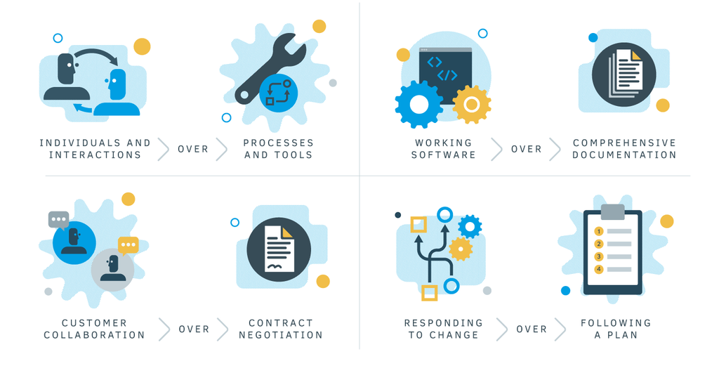

Abb. 1.a.8: SCRUM Manifesto

**Daten** wurden seit den 1970er Jahren unterstützend zur **Entscheidungsfindung** und in Produktionsprozessen eingesetzt. Im Gegensatz dazu sind Daten heutzutage oft auch das finale Produkt.

**Glossar:** **LVS** = Lagerverwaltungssystem **SCM** = Supply-Chain-Management **ERP** = Enterprise-Resource-Planning **MRP** = Material Requirements Planning **CRM** = Customer-Relationship-Management

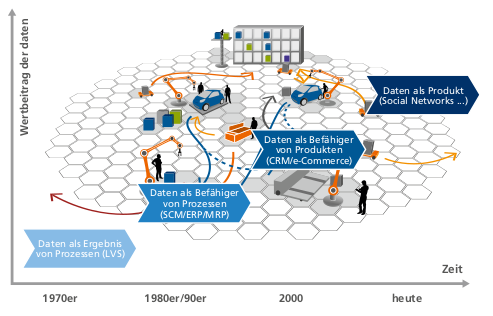

Abb. 1.a.6: Rolle der Daten der Digitalisierung

### 1.b) Bedeutung von Daten und deren Digitalisierung

Die **Informationslogistik** befasst sich mit Informationsflüssen in Organisationsstrukturen. Das Ziel der Informationslogistik ist die Versorgung aller erforderlichen Akteure in einer Organisation oder zwischen Organisationen mit den relevanten Daten zum richtigen Zeitpunkt.

Durch die ständig wachsende **Menge an Daten** aus verschiedensten Lebensbereichen können Produkte und Dienstleistungen digital erweitert und miteinander verknüpft werden. Dieser Entwicklung entsprechend findet auch auf wirtschaftlicher Ebene eine Kehrtwende, von der klassischen Produkt- und Servicezentrierung hin zu einer Fokussierung auf den individuellen Konsumenten und eine auf dessen Bedürfnisse maßgeschneiderte Lösung statt.

Die **Schnittstellen** zwischen den einzelnen Akteuren, vor allem diejenigen zum Kunden, müssen neu definiert werden um den Bedürfnissen nach individuellen Produkten und Dienstleistungen gerecht zu werden. Daten werden hierzu **analysiert** und der Erkenntnisgewinn fließt in die Geschäftsprozesse ein.

#### 5 Formen der Datenanalyse

Die nun folgenden **5 Formen der Datenanalyse** unterscheiden sich in ihren Zielen, Ihren Methoden und den daraus gewonnenen Erkenntnissen.

##### a) Die deskriptive Datenanalyse

Die deskriptive Datenanalyse, auch als **beschreibende Datenauswertung** bezeichnet, konzentriert sich auf die **Daten aus der Vergangenheit**. Sie ordnet und strukturiert empirische Daten. Durch die Datenauswertung soll die Fragestellung beantwortet werden: “Was ist passiert?”.

Beispielsweise liefert sie Informationen wie den Umsatz im letzten Quartal oder die Art und die Anzahl von Serviceanfragen. Um diese Ergebnisse zu liefern, kann die deskriptive Analyse Daten aus verschiedenen Quellen extrahieren und die **Informationen aggregieren**, **ordnen** und **strukturieren**. Die deskriptive Analyse liefert aber keine Antworten auf Fragen wie: “Warum ist etwas geschehen?”. Oft werden deskriptive Datenanalysen mit anderen Analysemethoden kombiniert.

##### b) Die explorative Datenanalyse

Ziel der explorativen Datenanalyse ist es, **Zusammenhänge in Daten** zu finden und Hypothesen zu generieren. Vor der explorativen Analyse existiert nur ein begrenztes Wissen über die Zusammenhänge der Daten und Variablen. Typischer Anwendungsbereich für die explorative Datenanalyse ist das Data Mining. Durch das Aufdecken von Zusammenhängen mit Hilfe der explorativen Datenanalyse lassen sich Rückschlüsse auf die Ursachen der Vorgänge ziehen.

##### c) Die diagnostische Datenanalyse

Die diagnostische Datenanalyse beschäftigt sich ganz konkret mit der  
Fragestellung: “Warum ist etwas geschehen?”. Indem sie **historische** und  
andere Daten vergleicht, **Muster identifiziert** und **Zusammenhänge** aufdeckt,  
findet sie Ursachen oder gegenseitige Wechselwirkungen. Mit Hilfe der  
diagnostischen Datenanalyse können Unternehmen konkrete Problemstellungen  
lösen, da die Ursachen aufgezeigt werden.

##### d) Die prädiktive Datenanalyse

Die prädiktive Datenanalyse, auch als Vorhersageanalyse bzw. Predictive Analytics bezeichnet, gestattet den Blick in die Zukunft. Es wird die Fragestellung beantwortet: “Was wird passieren?”.

Um die richtigen Vorhersagen zu treffen, nutzt die prädiktive Datenanalyse die Ergebnisse der zuvor beschriebenen **deskriptiven**, **explorativen** oder **diagnostischen Analysemethoden** sowie **Algorithmen** und **Methoden** der **Künstlichen Intelligenz (KI)** und des **Maschinellen Lernens (ML)**.

Durch das Finden von **Zusammenhängen**, **Ursachen** und **zeitlichen Tendenzen** werden zukünftige Trends vorhersagbar. Die Vorhersagewahrscheinlichkeit und -genauigkeit hängen maßgeblich von der Qualität der Daten, den gefundenen Mustern, Zusammenhängen und Trends sowie von der Intelligenz der Algorithmen ab. Beispielsweise lassen sich zukünftige Umsätze vorhersagen oder das Kundenverhalten prognostizieren.

##### e) Die präskriptive Datenanalyse

Die präskriptive Datenanalyse ist die komplexeste und aufwendigste Analysekategorie. Sie liefert Unternehmen aber einen immensen Mehrwert, indem Sie die Fragestellung beantwortet: “Mit welchen Maßnahmen lassen sich Probleme beseitigen, zukünftige Entwicklungen positiv beeinflussen oder die gesetzten Ziele erreichen?”.

Präskriptive Datenauswertungen basieren auf **historischen** und **aktuellen Daten** interner und externer Datenquellen. Sie nutzen Ergebnisse zuvor beschriebener Analysekategorien. Die Vorhersagen werden kontinuierlich aktualisiert. Zum Einsatz kommen ML- und KI-Algorithmen, neuronale Netzwerke, Simulationen und Business Regeln.

**Digitalisierung** bezeichnetdas Umwandeln von analogen Werten in ein digitales Format bzw. digitale Repräsentation), welche zu verarbeiten sind.

Hierzu werden **Daten** IT-technisch gespeichert, intechnisch gespeichert, in Form von Bits & Bytes. Diese werden in verschiedenen Stellenwertesystemen und Zeichensätzen dargestellt.

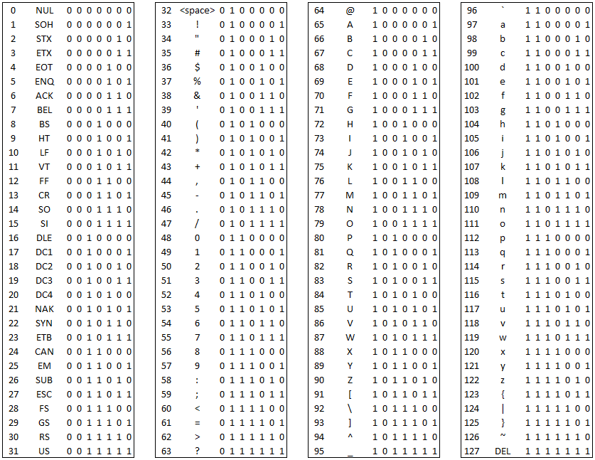

Abb. 1.b.2: ASCII Zeichensatz

#### Speichereinheiten

Die kleinste Einheit ist *1 Bit*. “Bit” steht für “Binary Digit”. In der Informatik wird im Binärsystem gerechnet, was bedeutet, dass es nur zwei Zustände gibt – *an / aus* bzw. *0 / 1*. Der Computer rechnet mit diesen Zahlen, dem binären Dualsystem. Daher wird der Faktor *1024* genutzt, denn im Binärsystem kommt die Zahl *1000* nicht vor, sondern nur *1024* (*1, 2, 4, 16, 32, 64, 128, 256, 512, 1024* = *10* Bit.

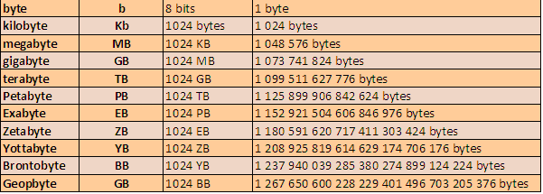

Abb. 1.b.3: Tabelle der Speichergrößen

#### Stellenwertsysteme

**Dualsystem / Binärsystem:** Basis *2*, Ziffern *0* und *1*

**Oktalsystem:** Basis *8* (= 23), Ziffern *0* bis *7*

**Dezimalsystem:** Basis *10*, Ziffern *0* bis *9*

**Hexadezimalsystem:** Basis *16 (*24*)*, Ziffern *0* bis *9* und *A* bis *F*

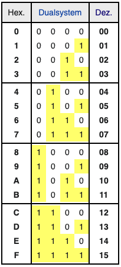

Abb. 1.b.4: Stellenwertsysteme

#### Zeichensätze

**ASCII:** Früher Standardzeichensatz, *7* Bit, Kodierung von *128* Zeichen möglich

**ANSI:** *8* Bit Zeichensatz, Kodierung von *256* Zeichen möglich. Die Zeichen *0* bis *127* sind der ASCII-Zeichensatz und die Werte zwischen *128* und 255 sind Sonderzeichen.

**ISO-8859:** Set von Zeichensätzen, die auf *8* Bit basieren und *256* Zeichen abbilden. Die ersten *128* Zeichen (0 - 127) sind immer identisch mit dem ASCII-Zeichensatz. Die zweiten *128* Stellen enthalten spezielle Zeichen. Z.B. ISO-8859-1: schriftspezifische Zeichen für westeurop. / amer. Sprachen

**Unicode:** Universeller Zeichensatz zur Darstellung aller Zeichen aller Sprachen. *16* Bit gleich *65536* Zeichen (erste Byte auf null gesetzt -> ASCII / ANSI)

**UTF-8: „**8-Bit Unicode Transformation Format“, unterstützt bis zu *4* Byte, mit denen sich *1.114.112* Zeichen abbilden lassen.

#### Textbasierte Dateiformate

**CSV (comma-separated values) Dateiformat**: Eine Textdatei zum Austausch einfach strukturierter Daten, die Trennung der Daten erfolgt mit dem „,“ Zeichen, Zeichenkodierung 7-Bit-ASCII-Code. Beispiel: alter,geschlecht,note_mathe,note_annahme,kopf,angst,interesse,praxis 44,3,1,1,60,1,1,30 22,1,2,4,50,3,3,50

**XML:** e**X**tensible **M**arkup **L**anguage, wie bei HTML sind Daten von Markierungen umgeben. Es sind Struktur und Bedeutungen zu vergeben. Bsp.:

```xml
<?xml version="1.0"?>
<CAT>
  <SUBCAT>
    <NAME>Izzy</NAME>
    <BREED>Siamese</BREED>
    <AGE>6</AGE>
    <ALTERED>yes</ALTERED>
    <DECLAWED>no</DECLAWED>
    <LICENSE>Izz138bod</LICENSE>
    <OWNER>Colin Wilcox</OWNER>
  </SUBCAT>
</CAT>
```

#### (Text-)Editoren

Um Textdateien jeder Art (aber auch Code wie HTML oder C#) einfach auszu-  
lesen und zu bearbeiten gibt es sogenannte Text-Editoren. Hier eine Auswahl  
an kostenlosen Programmen für Windows, Mac und iPadOS.

**Brackets:** Für *Mac (und Windows)*, einfach zu bedienen und etliche neue

Funktionen können durch Erweiterungen hinzuzugefügt werden  
https://github.com/adobe/brackets/releases/download/release-1.14.2/Brackets.Release.1.14.2.dmg

**NotePad++:** Für *Windows*, mächtige Software mit vielen Funktionen und

Erweiterungen. Wird häufig im Produktiveinsatz verwendet.

https://github.com/notepad-plus-plus/notepad-plus-plus/releases/download/v8.1.9/npp.8.1.9.Installer.x64.exe

##### Kodex:

Für *iPadOS*, simpel und leicht zu bedienen Download über den Apple AppStore

#### Line Feed (LF) vs. Carriage Return + Line Feed (CRLF)

**LF**: Unter Linux / Unix und Mac wird mittels *LF* eine neue Zeile eingeleitet (auch mit *Newline* oder *\n* bezeichnet).

**CRLF:** Unter Windows-Systemen wird mit *CR* eingeleitet (auch mit *Carriage Return* oder *\r* bezeichnet) der Cursor an den Anfang der Zeile gesetzt und mit *LF* die neue Zeile eingeleitet.

[figure not shown]

Abb. 1.b.5: NotePad++ - CRLF

#### Grundbegriffe des Technical Applications & Data Management

Weiterhin muss je nach Anwendungsfall der eigentliche **Ort der Datenanalyse** ausgewählt werden. Je nach Anforderung ist es sinnvoll Daten zentral zu verarbeiten, wofür sie erst an einen zentralen Ort transportiert werden müssen. Dies ist erstens aufwändig und zweitens übersteigt die Menge an Daten womöglich die Systemkapazitäten.

Der Ansatz, die Daten remote, sprich dort zu verarbeiten, wo sie entstehen, bietet die Chance den Prozess effizienter zu gestalten, und zusätzlich nicht nur statische Datenbestände, sondern auch kontinuierlich Ströme von Daten in Echtzeit auszuwerten.

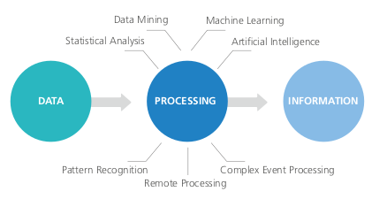

Abb. 1.b.7: Methoden zur Extraktion von Informationen

*Datenanalyse ist praktisch betrachtet*

das **Einlesen**, **Aufbereiten**, **Modellieren**, **Visualisieren** und **Kommunizieren** von Daten.

Die Schritte *Aufbereiten*, *Visualisieren* und *Modellieren* folgen keinem starren Ablauf.

Die Datenanalyse ist in einen Rahmen eingebettet. Dieser beinhaltet *philosophische* und *technische* Grundlagen

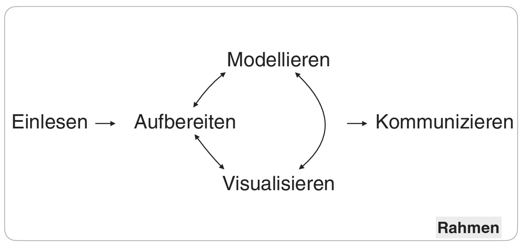

Abb. 1.b.8: Der Rahmen der Datenanalyse

### 1.c) Ziele der Datenanalyse und Stand der Technik

Ziel der **Datenanalyse** ist es, aus den vorhandenen Daten durch Anwendung verschiedener Methoden und Analyseverfahren die jeweils benötigten Erkenntnisse oder Informationen zu gewinnen.

Durch Technologien wie **KI (Künstliche Intelligenz)** und **Machine Learning**, lassen sich automatisiert große Datenmengen analysieren und zur Verbesserung von Geschäftsprozessen heranziehen.

Große Rechenzentren können diese Analysen binnen kurzer Zeit durchführen.

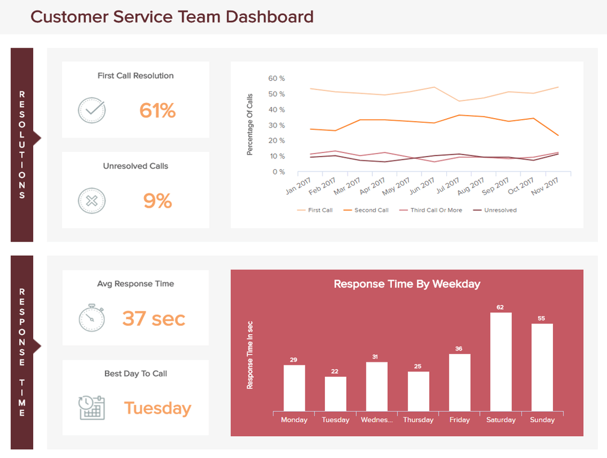

### 1.d) Einführung in die Begriffe BI, Reporting und Big Data

Es sind grundsätzlich **zwei verschiedene Blickwinkel** der Daten- auswertung zu Unterscheiden: 1. **Business Intelligence** „Was ist in der Vergangenheit bis heute geschehen und warum ist es geschehen?“. Die Business Intelligence findet Muster und Trends, zielt aber nicht darauf ab, die zukünftigen Entwicklungen vorherzusagen. 2. **Business Analytics** „Warum ist etwas geschehen und was bedeutet das für die Zukunft?”. Es werden die verantwortlichen Faktoren und kausalen Zusammen- hänge für die Geschehnisse und Abläufe ermittelt. Diese nutzt Business Analytics, um Vorhersagen über zukünftige Entwicklungen zu machen.

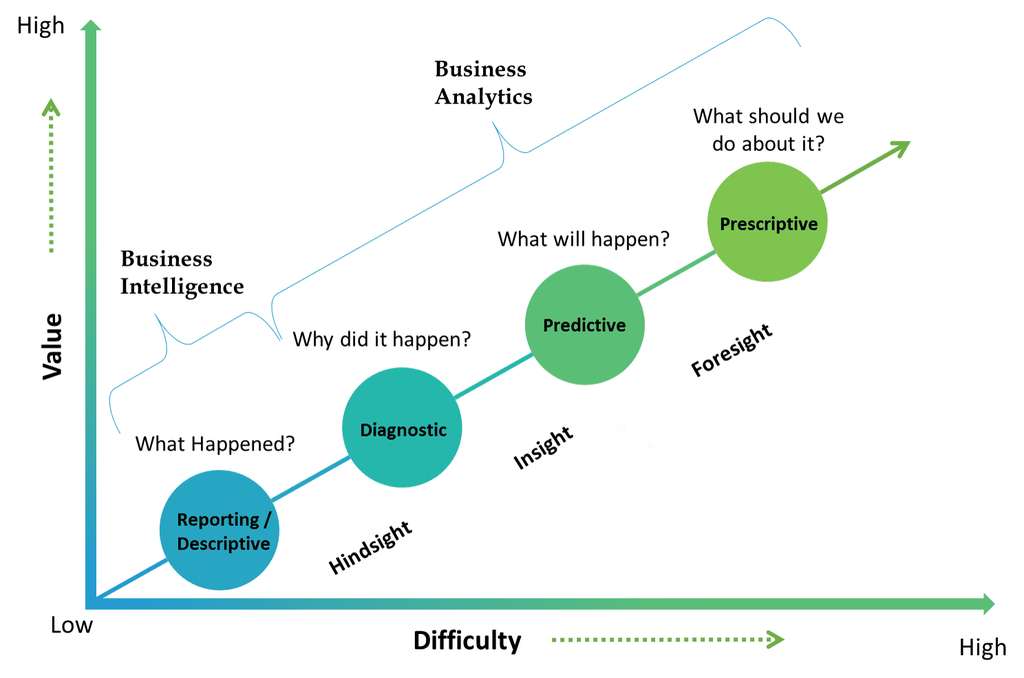

Abb. 1.d.1: Formen der Datenanalyse

#### Reporting

Der Begriff Reporting beschreibt das **systematische Erstellen** von **Berichten** auf Basis relevanter Unternehmensdaten  
und Informationen.

Wichtigstes Ziel des Reportings ist die Unterstützung der Führungs- und Entscheidungsprozesse in den verschiedenen Unternehmensbereichen.

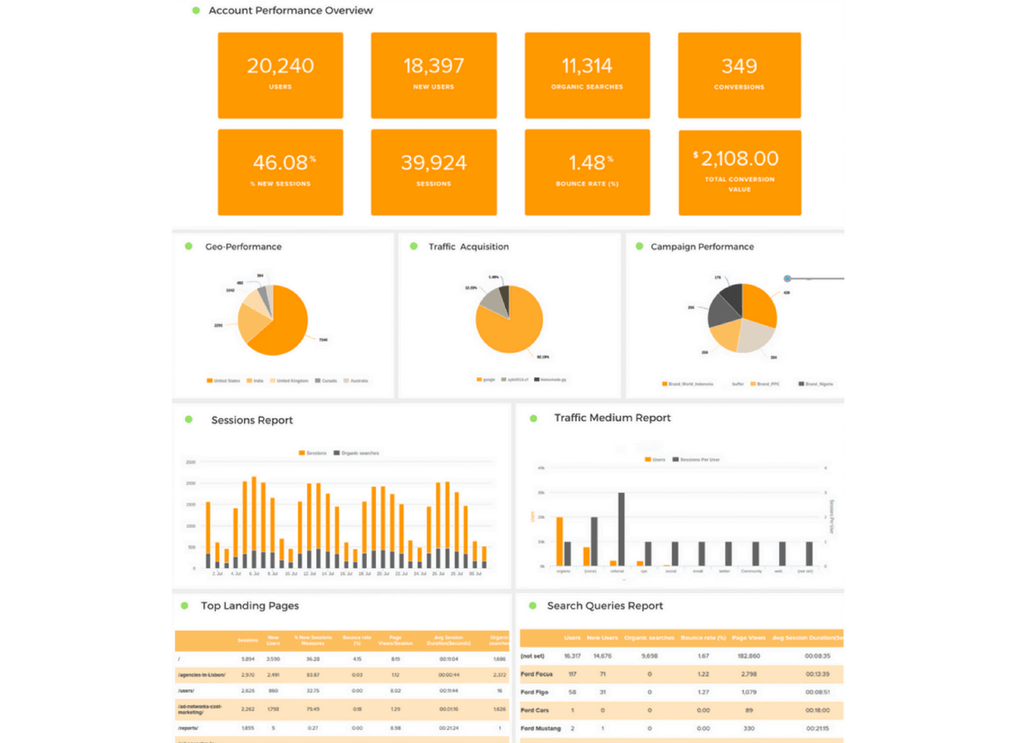

Abb. 1.d.2: Dashboard einer Reporting Software

### 1.d) Einführung in die Begriffe BI, Reporting und Big Data

#### Big Data

Big Data steht für die **große Mengen** an **Daten** – Daten in der Größenordnung von Zettabytes, die von Computern, Mobilgeräten und elektronischen Sensoren produziert werden.

Anhand dieser Daten können Unternehmen **Entscheidungen** treffen, Prozesse und Richtlinien verbessern und kundenorientierte Produkte, Services und Erfahrungen entwickeln.

Big Data werden nicht nur wegen ihres Umfangs als „groß“ bezeichnet, sondern auch wegen der **Vielfalt** und **Komplexität** ihrer **Beschaffenheit**.

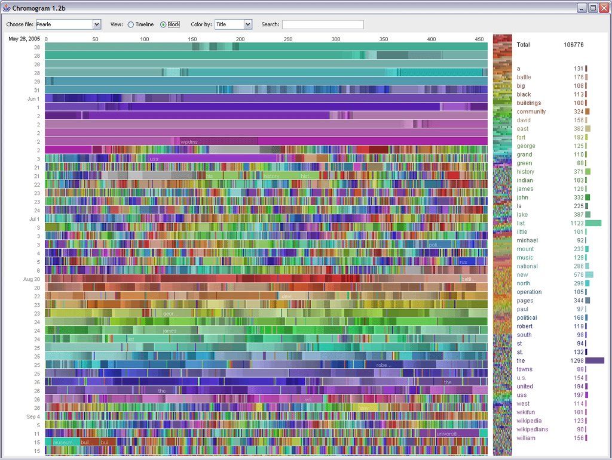

Abb. 1.d.3: Aktivität eines Wikipedia-Bots

## Technical Applications

- Einführung in die technische Datenerfassung
- Verschiedene Quellen von Daten und deren Zusammenhänge
- Speicherung der Daten, Datenbanken, Datawarehouses
- Grundlagen der Technischen Applikationen
- Einführung in verschiedene Anwendungen und deren Darstellung mit Vor- und Nachteilen

### 2.a) Einführung in die technische Datenerfassung

Die **Anforderungen** von *Datenanalyse*, *Data Mining*, *maschinellem Lernen* und auch der *klassischen Statistik* gleichen sich. Die geteilten **Wissensgebiete** zur Anwendung dieser Verfahren sind:

- Philosophische Grundlagen
- Mathematisch-statistische Anwendungen
- Computerwissenschaftliche Anwendungen
- Fach- und Branchenkenntnis

[figure not shown]

Abb. 2.a.1: Buch – Einführung in die Datenverarbeitung

#### *Microsoft Excel*

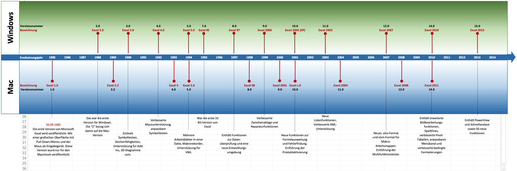

Abb. 2.a.2: Zeitschiene *Microsoft Excel*

#### Grundbegriffe

**Daten** (die Einzahl Datum ist ungewöhnlich) kann man als Informationen, die eine Funktion haben, beschreiben.1 Somit sind, von für den Menschen nützliche Daten, beliebige Daten ohne Zweck und Systematik ausgenommen (Sauer, 2019). Der Zweck muss demnach zumindest Fachpersonal bekannt und gängigen Methoden der **Datenerfassung** und **Datenverarbeitung** zugänglich sein.

Daten bestehen somit aus **Merkmalen** (Variablen). Hinzu kommen **Beobachtungseinheiten** (Fälle, Beobachtungen). Eine **Tabelle** mit ihren rechtwinkligen Achsen der Zeilen und Spalten hält im Kopf die **Variablennamen** und in den einzelnen Zeilen, die jeweils dem Merkmal zugordneten **Objekte**.

#### Verschiedene Quellen von Daten und deren Zusammenhänge

Die Herkunft von Daten wird differenziert betrachtet.

##### Primärdaten

- Beobachtung
- Befragung
- Experimentell
- Sekundärdaten
  - Interne Quellen
  - Externe Quellen

### 2.b) Verschiedene Quellen von Daten und deren Zusammenhänge

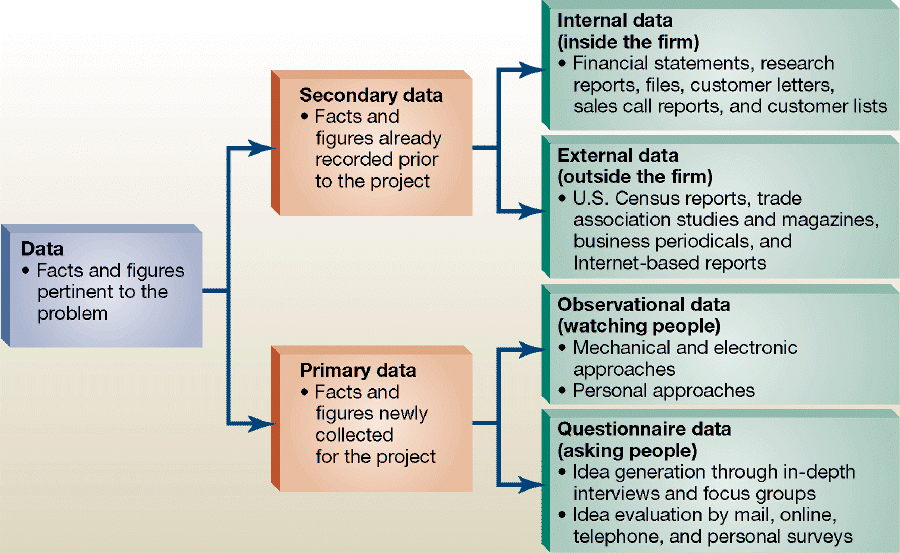

Abb. 2.b.1: Primär- und Sekundärdaten

#### Speicherung von Daten in Dateien

Typischer Weise werden Daten in *CSV* und *XML* **Dateien** gespeichert.

Einfache **Text-Dateien** (*.txt*) oder **Textverarbeitungsdateien** mit Endungen (Suffix) wie *.docx* (Microsoft Word) bzw. .xlsx (Microsoft Excel) und offene Formate (*.odt*) von Open-Source Office Suiten, eignen sich aufgrund der evtl. fehlenden Bibliotheken bzw. der fehlenden Struktur in den technischen Applikationen eher weniger.

Ebenso denkbar ist die Speicherung in einer **Binärdatei**. Hier sind die Daten in Bitmustern gespeichert und nur mit entsprechenden Import-Bibliotheken der technischen Applikationen lesbar.

### 2.c) Speicherung der Daten, Datenbanken, Datawarehouses

#### Data Warehouse

Ein **Data Warehouse** ist eine Art **Datenmanagementsystem**, mit dem BI- Aktivitäten (Business Intelligence), insbesondere Analysen, aktiviert und unterstützt werden. Data Warehouses dienen ausschließlich zur Durchführung von Abfragen und Analysen und enthalten häufig große Mengen an Verlaufsdaten. Die Daten in einem Data Warehouse stammen üblicherweise aus einer Vielzahl von Quellen, z. B. aus Anwendungsprotokolldateien und Transaktionsanwendungen.

Ein Data Warehouse zentralisiert und konsolidiert **große Datenmengen** aus mehreren Quellen. Die Analysefunktionen ermöglichen es Unternehmen, **wertvolle Geschäftsinformationen** aus ihren Daten abzuleiten, um die **Entscheidungsfindung** zu verbessern. Im Laufe der Zeit wird ein Verlaufsdatensatz erstellt, der für Daten- und Geschäftsanalysten von unschätzbarem Wert sein kann. Aufgrund dieser Funktionen kann ein Data Warehouse als die „*einzige Quelle wahrer Daten*“ eines Unternehmens betrachtet werden.

#### Speicherung von Daten in Computerspielen

Eine Datenbank ist ein elektronisches Verwaltungssystem, das besonders mit großen Datenmengen effizient, widerspruchsfrei, dauerhaft umgehen muss und logische Zusammenhänge digital abbilden kann.

Es können Datenbestände aus verschiedenen Teilmengen zusammengestellt und bedarfsgerecht für Anwendungsprogramme und deren Benutzern angezeigt werden.

Heutzutage kann eine Datenbank viele Informationen beinhalten. Komplexe Datenbanken werden oft in Warenwirtschaftssystemen (abgekürzt WWS oder WaWi) verwendet oder auch zur Verarbeitung von Sozial- und Gesundheitsdaten (Sozialversicherungsträger, Sozialhilfeträger, Versorgungsbehörden, Haus- und Fachärzte).

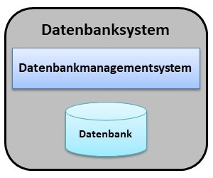

Abb. 2.c.1: Datenbanksysteme

Spiele verwalten eine Menge Daten. Zum einen die Werte und Eigenschaften von In-Game Gegenständen, sowie die erhobenen Daten von Spieler- Interaktionen und Verhalten (z.B Highscores).

Da Spiele oftmals im Hinblick auf **Performance** konzipiert werden, müssen diese Daten effizient und konsistent gespeichert werden. Hierzu eigenen sich **Datenbanksysteme** um große Datenmengen zu speichern.

[figure not shown]

Abb. 2.c.2: *Microsoft SQL Studio*